# Capstone Presentation - Next Word Predictor

November 27, 2019

## Coursera Data Science Capstone - Final Project Submission

- This is the final, peer-graded project for the Data Science Specialization at Coursera.
- The primary assignment is developing a Shiny app that takes as input a phrase (multiple words) in a text box input and outputs a prediction of the next word.
- This capability can be applied to several use cases such as simplifying texting on a smartphone, assisting disabled users, or development of an AI chat-bot to reduce customer support costs.
- The training data set included text from news websites, twitter feeds, and blog posts. Using R-based text mining and natural language, an algorithm was created to predict the next word of inputed text.

## Learning Algorithm

- We used the N-Gram function to develop our algorithm. N-Grams are continguous, sub-sequenced of length n of a given sequence.
- The N-Gram function takes in a sequence (vector), text in this case as input.
- The N-Gram function returns a positive integer giving the length of contiguous sub-sequences to be computed.
- For example, 2-grams for the sentence “The cow jumps over the moon” are: “the cow”, “cow jumps”, “jumps over”, “over the”, “the moon”.
- The N-Grams models were cleansed and tabulated using text from news articles, twitter posts, and blogs.
- The resulting data set (corpus) is comprised of a 1-grams, 2-grams, 3-grams, through 6-grams.

## Prediction Model

- We used Katz’s back-off model as our next-word prediction model.
- This model first searches the 6-grams in the corpus for a prediction, then “backs-off” to the 5-grams if the first search is unsuccessful.
- The process continues backwards to the 4-grams, 3-grams, and 2-grams.
- If the 2-gram search is unsuccessful, then the most frequent 1-grams in the corpus are output as the predicted word.

## App Usability

- The screenshot below illustrates the Shiny next-word prediction application.
- Use of the app is intuitive. Simply type in or copy text into the input box and the predicted text will display.

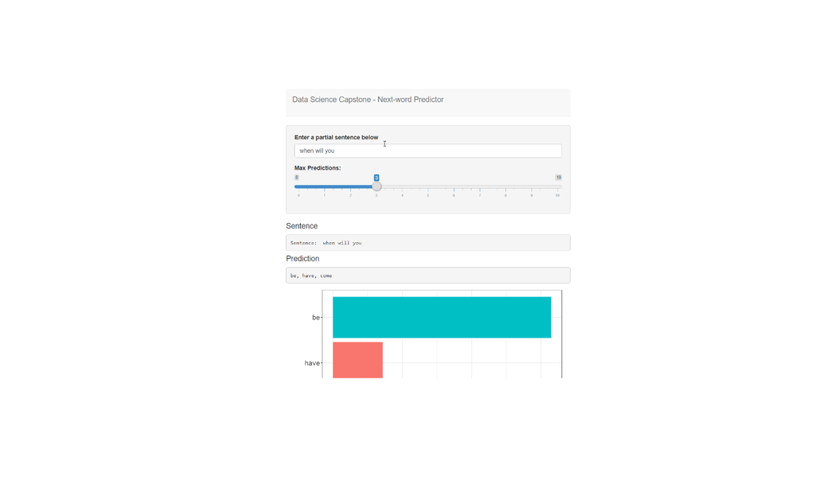

## References

- Access the Shiny App: https://dbrad4d.shinyapps.io/ds_capstone
- This presentation on Rpubs: http://rpubs.com/dbrad4d/ds_capstone
- Source files on Github: https://github.com/dbrad4d/ds_capstone
- Coursera project description: https://www.coursera.org/learn/data-science-project/peer/EI1l4/final-project-submission
- RDocumentation for n-grams: https://www.rdocumentation.org/packages/NLP/versions/0.2-0/topics/ngrams
- Katz’s back-off model: https://en.wikipedia.org/wiki/Katz%27s_back-off_model